# 1 Harmonisation des données SAPM

Dans cette section, nous passons en revue plusieurs jeux de données ayant documenté les aires protégées à Madagascar à différentes périodes. Ces données, issues de sources officielles, ont été produites et mises à jour par différentes institutions. Nous les harmonisons en appliquant un ensemble de traitements standardisés :

- Correction des erreurs topologiques.
- Homogénéisation des formats de fichiers et des projections.
- Consolidation et validation des attributs descriptifs.
- Construction d’une série temporelle cohérente des aires protégées de 2002 à 2024.

Ces opérations visent à rendre comparables des jeux de données produits à des moments différents et selon des logiques institutionnelles variées. Elles permettent la construction d’une série temporelle cohérente, indispensable à toute analyse historique ou comparative sur les dynamiques de conservation à Madagascar.

Ces opérations sont réalisées avec R, avec une série de package appropriés.

**Voir le code**

```r
# On charge les librairies nécessaires
library(tidyverse) # Aide à la manipulation de données
library(sf) # Pour traiter des données spatiales (vectorielles)
library(tmap) # Pour faire de jolies cartes
library(gt) # Pour faire de jolis tableaux

# Specify the source repository
data_dir <- "sources/"
# Specify CRS
my_crs <- 29702

# Cleans PA name columns only (e.g. NOM, SHORT_NAME, etc.)
# You must specify which columns to clean
clean_pa_names_cols <- function(df, name_cols) {
  df %>%
    mutate(across(
      all_of(name_cols),
      ~ .x %>%
        str_replace_all("[\r\n\t]", " ") %>% # replace line breaks, carriage returns, tabs with space
        str_squish() %>% # collapse multiple spaces into one
        str_trim() # remove leading/trailing whitespace
    ))
}
```

## 1.1 ANGAP 2002

Avant la création du SAPM, l’ANGAP était la seule entité chargée de gérer les aires protégées, et donc leurs données. L’ANGAP avait dans ce cadre transmis à l’institut national de géographie malgache (FTM) pour la mise à jour de la base de donnée topographique (BD 500).

**Voir le code**

```r
# Load and preprocess the shapefile
angap_2002 <- st_read(
  paste0(data_dir, "ap_angap BD 500/ap_angap.shp"),
  quiet = TRUE
) %>%
  st_set_crs(my_crs) %>% # Laborde Magasiaraka CRS
  clean_pa_names_cols(name_cols = "NOM") %>%
  mutate(
    has_info = ifelse(
      is.na(CLASSEMENT),
      "Attributs absents",
      "Attributs présents"
    ),
    has_name = case_when(
      is.na(NOM) ~ "Pas de nom",
      NOM == "Hors AP" ~ "Hors AP",
      .default = "Nommé"
    )
  )

# Separate datasets: "Pas de nom", "Hors AP", and "Nommé"
angap_pas_de_nom <- angap_2002 %>% filter(has_name == "Pas de nom")
angap_hors_ap <- angap_2002 %>% filter(has_name == "Hors AP")
angap_named <- angap_2002 %>% filter(has_name == "Nommé")

# Set tmap to interactive mode
tmap_mode("view")

# Create the map with three layers
tm_shape(angap_named) +
  tm_fill(
    col = "has_info",
    id = "NOM",
    popup.vars = names(st_drop_geometry(angap_named))
  ) +
  tm_borders(col = "black", lwd = 0.5) + # Default borders for named features
  tm_shape(angap_pas_de_nom) +
  tm_fill(
    col = "has_info",
    id = "NOM",
    popup.vars = names(st_drop_geometry(angap_pas_de_nom)),
    legend.show = FALSE
  ) +
  tm_borders(col = "red", lwd = 3) + # Thick red borders for "Pas de nom"
  tm_shape(angap_hors_ap) +
  tm_fill(
    col = "has_info",
    id = "NOM",
    popup.vars = names(st_drop_geometry(angap_hors_ap)),
    legend.show = FALSE
  ) +
  tm_borders(col = "blue", lwd = 3) + # Thick blue borders for "Hors AP"
  tm_add_legend(
    type = "fill",
    labels = c("Pas de nom", "Hors AP"),
    col = c("red", "blue"),
    lwd = c(3, 3, 0.5),
    title = "Contour"
  )
```

[interactive chart not shown]

Le champ “classement” de ce jeu de données fait référence à des décrets parus jusqu’en 1998, mais il fait aussi référence à 11 entités qui n’ont pas de métadonnées les caractérisant.

On effectue donc les opération suivantes : identification des polygones sans nom qui font visiblement partie d’une AP, regroupement des polygones simples en multipolygones s’ils ont les mêmes attributs, et suppression des polygones explicitement référencés comme “Hors AP”.

**Voir le code**

```r
angap_2002 <- angap_2002 %>%
  select(APBON = APBON_, APBON_ID, NOM, TYPE_AP, CLASSEMENT, IUCN) %>%
  mutate(
    NOM = case_when(
      # Rename the patches visibly included in PAs
      APBON_ID %in% c(100006, 100005) ~ "Ranomafana",
      APBON_ID %in% c(100002, 100003, 100004) ~ "Masoala",
      APBON == 27 ~ "Baie de Baly",
      .default = NOM
    )
  ) %>%
  group_by(across(NOM:IUCN)) %>%
  summarize(geometry = st_union(geometry)) %>%
  ungroup() %>%
  filter(NOM != "Hors AP") # Discard the explicitely labelled as not PA

write_rds(angap_2002, "data/no_id/angap_2002.rds")

tm_shape(angap_2002) +
  tm_polygons()
```

[interactive chart not shown]

Le résultat est présenté dans la carte ci-dessus.

## 1.2 MNP 2010

Données historiques MNP fournies par le responsable des données spatiales de l’institution (coauteur du présent travail). Elles représentent un état des périmètres d’aires protégées autour de 2010. Le seul attribut pertinent est le nom.

**Voir le code**

```r
# Chargement des données historiques MNP
mnp_2010 <- st_read(
  "data/no_id/allAP_ap2000_2010_Merge_Lab/allAP_ap2000_2010_Merge_Lab.shp",
  quiet = TRUE
) %>%
  st_set_crs(29701) %>% # CRS d’origine
  st_transform(my_crs) # Harmonisation en Laborde

# Nettoyage et standardisation des noms
mnp_2010 <- mnp_2010 %>%
  mutate(
    NOM = NAME_BASE %>%
      str_remove("\\s*-\\s*2000\\s*2010$") %>%
      str_remove("\\s+[0-9]+$") %>% # remove trailing numeric part
      str_replace_all("[\r\n\t]", " ") %>%
      str_squish() %>%
      str_trim()
  )

# Conservation des seuls attributs pertinents
mnp_2010 <- mnp_2010 %>%
  select(NOM)

# Correction des géométries et consolidation par aire protégée
mnp_2010 <- mnp_2010 %>%
  st_make_valid() %>%
  group_by(NOM) %>%
  summarise(
    geometry = st_union(geometry),
    .groups = "drop"
  ) %>%
  st_collection_extract("POLYGON") %>%
  st_cast("MULTIPOLYGON")

# Sauvegarde du jeu de données harmonisé
write_rds(mnp_2010, "data/no_id/mnp_2010.rds")

# Visualisation rapide de contrôle
tm_shape(mnp_2010) +
  tm_borders(col = "black")
```

[interactive chart not shown]

## 1.3 SAPM 2010

**Voir le code**

```r
sapm_2010 <- st_read(
  paste0(data_dir, "Vieilledent_sapm_20101220/AP-NAP_38s.shp"),
  quiet = TRUE,
  options = "ENCODING=WINDOWS-1252"
) %>%
  st_transform(my_crs) %>%
  clean_pa_names_cols(name_cols = "NOM")

write_rds(sapm_2010, "data/no_id/sapm_2010.rds")

tm_shape(sapm_2010) +
  tm_borders(col = "purple")
```

[interactive chart not shown]

## 1.4 Evolution du SAPM 2002-2011

Ce jeu de données a été publié en ligne par un consultant du SAPM, avec la référence suivante : Evolution of the Madagascar Protected Area System (SAPM), Tom Allnut, https://hub.arcgis.com/content/4218737646234c7cab1c7a20e2c2489d/about

It is provided as a .mpk, which is in fact a zip including shapefiles. We convert to Zip and open the shapefiles.

**Voir le code**

```r
# Specify the directory path
dir_path <- paste0(data_dir, "sapm_evolution_2012/commondata/data1")

# List all .shp files in the directory
shapefile_paths <- list.files(
  path = dir_path,
  pattern = "\\.shp$",
  full.names = TRUE,
  recursive = TRUE
)

# Extract the filenames without the full path
shapefile_names <- basename(shapefile_paths)

# Filter shapefiles with a date in the filename (e.g., "2008", "2009", etc.)
date_shapefiles <- shapefile_paths[str_detect(shapefile_names, "20[0-9]{2}")]

# Load and bind the shapefiles
sapm_evol_2001_2011 <- date_shapefiles %>%
  map(
    ~ st_read(.x, quiet = TRUE) %>% # Read each shapefile
      clean_pa_names_cols(name_cols = "NOM")
  ) %>% # and clean PA name
  reduce(bind_rows) %>%
  mutate(YEAR = str_extract(YEAR, "\\d{4}")) %>% # Extract the 4-digit year
  st_transform(crs = my_crs) # On passe les données en laborde malgache

sapm_evol_2001_2011 %>%
  filter(YEAR == 2002) %>%
  tm_shape() +
  tm_borders(col = "blue") +
  tm_shape(angap_2002) +
  tm_fill(col = "red", alpha = 0.5)
```

[interactive chart not shown]

**Voir le code**

```r
# Save the data to a specified path
write_rds(sapm_evol_2001_2011, "data/no_id/sapm_evol_2001_2011.rds")
```

La superposition des limites extraites de cette série temporelle avec celles issues de la base ANGAP 2002 permet de visualiser les premiers recouvrements et écarts.

## 1.5 SAPM 2017

Ce jeu de données nous a été remis par la FAPBM. Il s’agit visiblement des données SAPM mises à jour en mars 2017.

L’un des points du périmètre de l’aire protégée Andrafiamena Andavakoera (index 32, sommet numéro 841) est localisé de manière aberrante, formant un papillon et entraînant des erreurs topologiques. La fonction `st_make_valid` retire ce point aberrant.

**Voir le code**

```r
# Load and transform data
sapm_2017 <- st_read(
  paste0(data_dir, "sapm_201703017_om_surface/sapm_201703017_om_surface.shp"),
  options = "ENCODING=WINDOWS-1252",
  quiet = TRUE
) %>%
  st_transform(my_crs) %>%
  st_make_valid() %>%
  clean_pa_names_cols(name_cols = c("SHORT_NAME", "FULL_NAME"))

# Save the data
write_rds(sapm_2017, "data/no_id/sapm_2017.rds")

tm_shape(sapm_2017) +
  tm_polygons(col = "CATEG_IUCN")
```

[interactive chart not shown]

## 1.6 Compléments MNP (périmètres historiques)

Le MNP a fourni les périmètres historiques (antérieurs a 2002) de deux aires protégées pour lesquelles aucune donnée spatiale numérisée n’était disponible :

- **Ankarafantsika** : périmètre de la Réserve Naturelle Intégrale n. 7, délimitée par le Décret n. 66-242 du 1er juin 1966 (~57 000 ha). Ce périmètre est antérieur a la consolidation de 2002 qui a créé le Parc National (130 000 ha).
- **Mantadia** : périmètre original du Parc National créé par le Décret n. 89-011 du 11 janvier 1989 (~9 930 ha), avant l’extension de 2002 (Décret 2002-790, 15 480 ha).

**Voir le code**

```r
# Ankarafantsika RNI pre-2002 (Laborde, CRS absent du .prj)
anka_rni_pre2002 <- st_read(
  paste0(data_dir, "complement_MNP/Ankarafantsika_pre2002/Ankarafantsika_RNI_66242_20260409_v2_lab.shp"),
  quiet = TRUE
) |>
  st_set_crs(my_crs) |> # Laborde (EPSG:29702), CRS absent du fichier
  st_make_valid() |>
  clean_pa_names_cols(name_cols = "NOM") |>
  select(NOM) |>
  mutate(NOM = "Ankarafantsika")

write_rds(anka_rni_pre2002, "data/no_id/mnp_anka_rni_pre2002.rds")

# Mantadia PN pre-2002 (Laborde / Hotine Oblique Mercator)
mantadia_pre2002 <- st_read(
  paste0(data_dir, "complement_MNP/Mantadia_pre2002/MTD_05_2008.shp"),
  quiet = TRUE
) |>
  st_transform(my_crs) |> # Reprojection en Laborde
  st_make_valid() |>
  select(NOM) |>
  mutate(NOM = "Mantadia")

write_rds(mantadia_pre2002, "data/no_id/mnp_mantadia_pre2002.rds")

# Verification visuelle
tm_shape(anka_rni_pre2002) +
  tm_fill(col = "red", alpha = 0.3) +
  tm_borders(col = "red") +
  tm_shape(mantadia_pre2002) +
  tm_fill(col = "blue", alpha = 0.3) +
  tm_borders(col = "blue")
```

[interactive chart not shown]

## 1.7 Vahatra 2017

**Voir le code**

```r
load("sources/AP_Vahatra.rds")
AP_Vahatra %>%
  st_transform(my_crs) %>%
  clean_pa_names_cols(name_cols = c("nom", "full_name", "nom_wdpa")) %>%
  write_rds("data/no_id/vahatra.rds")
```

## 1.8 SAPM 2024

Ce jeu de données constitue l’état le plus récent de la base SAPM. Il inclut de nouvelles aires protégées récemment créées ainsi que des ajustements sur les périmètres existants.

**Voir le code**

Géométries invalides

Liste des géométries invalides

Index

Nom

Source

Geometrie

3

CM7B

NA

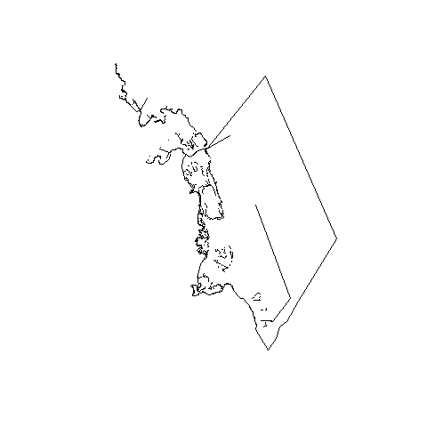

8

Mangiho

NA

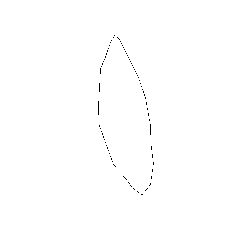

12

IVOHIBORO

D:\ASA AP\FOREST SHAPE.shp

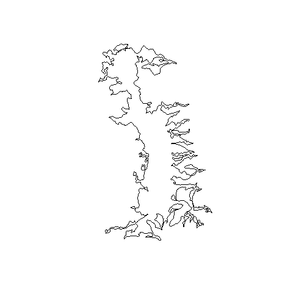

22

Behara Tranomaro

D:\SHAPE AP\Shapfile vaovao\sapm_201703017_dd\sapm_201703017_dd.shp

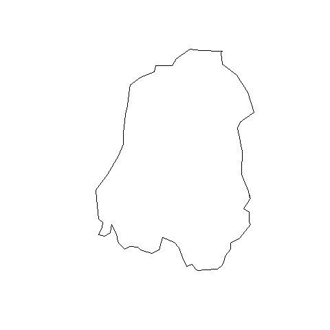

34

Torotorofotsy

D:\SHAPE AP\Shapfile vaovao\sapm_201703017_dd\sapm_201703017_dd.shp

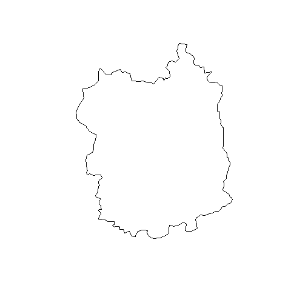

47

Andrafiamena Andavakoera

D:\SHAPE AP\Shapfile vaovao\sapm_201703017_dd\sapm_201703017_dd.shp

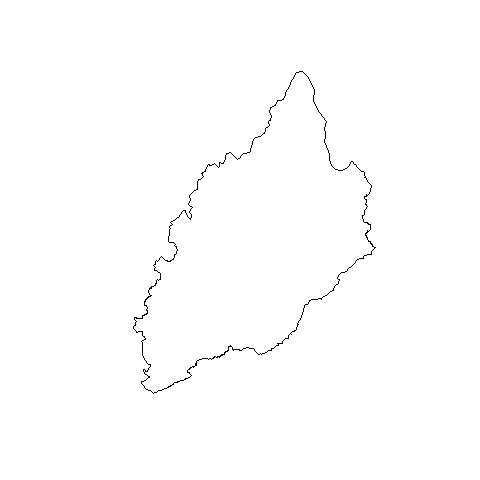

50

Menabe Antimena

D:\SHAPE AP\Shapfile vaovao\sapm_201703017_dd\sapm_201703017_dd.shp

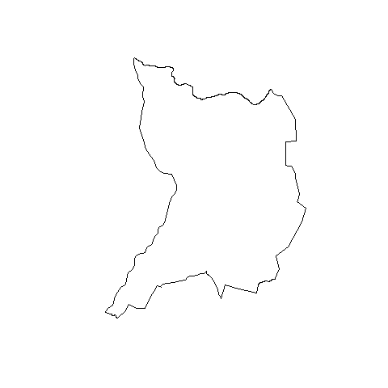

61

Analalava

D:\SHAPE AP\Shapfile vaovao\sapm_201703017_dd\sapm_201703017_dd.shp

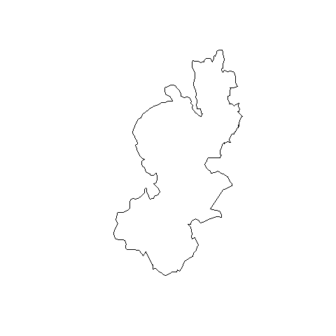

65

Makirovana Tsihomanaomby

D:\SHAPE AP\Shapfile vaovao\sapm_201703017_dd\sapm_201703017_dd.shp

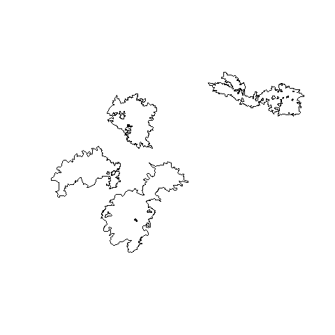

68

Pointe à Larrée

D:\SHAPE AP\Shapfile vaovao\sapm_201703017_dd\sapm_201703017_dd.shp

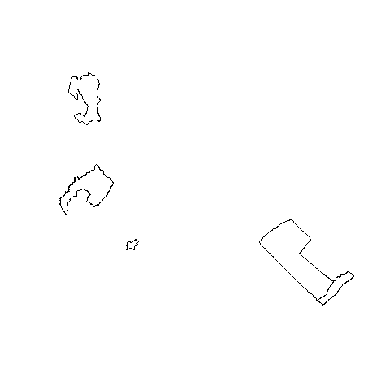

70

Antrema

D:\SHAPE AP\Shapfile vaovao\sapm_201703017_dd\sapm_201703017_dd.shp

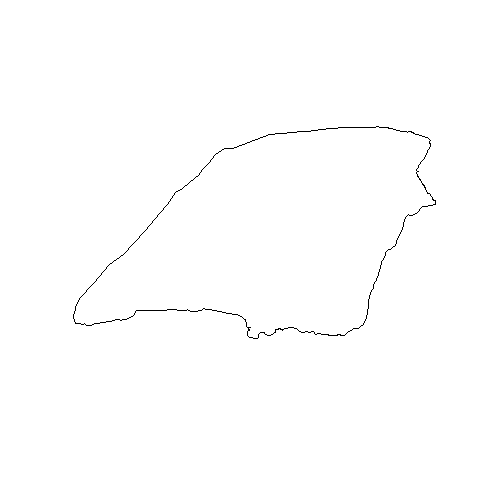

107

Pic d'Ivohibe

D:\SHAPE AP\Shapfile vaovao\sapm_201703017_dd\sapm_201703017_dd.shp

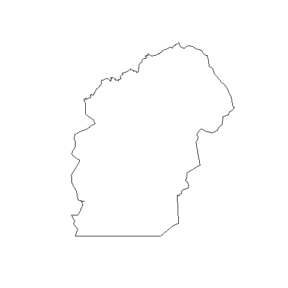

108

Ranomafana

D:\SHAPE AP\Shapfile vaovao\sapm_201703017_dd\sapm_201703017_dd.shp

[5 more figures not shown]

```r
# Load shapefile
sapm_2024 <- st_read(
  paste0(data_dir, "Shape AP mai2023/dernier version shape_ap_28042023.shp"),
  quiet = TRUE
)

# Check for invalid geometries
invalid_geometries <- sapm_2024 %>%
  st_zm(drop = TRUE, what = "ZM") %>% # <- remove Z and M before anything else
  rownames_to_column(var = "index") %>%
  rowwise() %>%
  mutate(is_valid = st_is_valid(geometry)) %>%
  filter(!is_valid) %>%
  select(Index = index, Nom = SHORT_NAME, Source = path)

# Create a folder to save the images
output_dir <- "invalid_geometry_plots"
dir.create(output_dir, showWarnings = FALSE)

# Loop through invalid geometries and save the plots
for (i in seq_len(nrow(invalid_geometries))) {
  geometry_index <- invalid_geometries$Index[i]

  # Generate a file name
  plot_file <- file.path(
    output_dir,
    paste0("geometry_", geometry_index, ".png")
  )

  # Save the plot
  png(plot_file)
  plot(st_geometry(sapm_2024[geometry_index, ]))
  dev.off()
}

# Add image file paths to the invalid geometries table
invalid_geometries <- invalid_geometries %>%
  mutate(
    Geometrie = paste0(output_dir, "/geometry_", Index, ".png")
  )

# Display the table with gt
if (nrow(invalid_geometries) == 0) {
  message("All geometries are valid.")
} else {
  invalid_geometries %>%
    st_drop_geometry() %>%
    gt() %>%
    text_transform(
      locations = cells_body(columns = Geometrie),
      fn = function(x) {
        local_image(filename = x, height = 100) # Embed local image with specified height
      }
    ) %>%
    tab_header(
      title = "Géométries invalides",
      subtitle = "Liste des géométries invalides"
    )
}
```

**Voir le code**

```r
# Now try to make this valid

sapm_2024_valid <- sapm_2024 %>%
  st_make_valid()

# Identify invalid geometries
invalid_geometries <- sapm_2024_valid %>%
  filter(!st_is_valid(geometry))

#  Print the names (or identifiers) of the invalid geometries
# Replace 'NOM' with the actual column containing the name or identifier
if (nrow(invalid_geometries) > 0) {
  cat("Invalid geometries found:\n")
  print(invalid_geometries$SHORT_NAME) # Adjust this to match your column name
} else {
  cat("All geometries are valid.\n")
}
```

```
Invalid geometries found:
[1] "CM7B"                     "Mangiho"
[3] "IVOHIBORO"                "Andrafiamena Andavakoera"
```

**Voir le code**

```r
# Step 5: Filter out invalid geometries for now to plot the valid ones
sapm_2024_valid_clean <- sapm_2024_valid %>%
  filter(st_is_valid(geometry)) %>%
  clean_pa_names_cols(name_cols = c("Name", "SHORT_NAME")) %>%
  st_transform(my_crs)

write_rds(sapm_2024_valid_clean, "data/no_id/sapm_2024.rds")

# Step 6: Plot the valid geometries using tmap
tm_shape(sapm_2024_valid_clean) +
  tm_fill(col = "blue", alpha = 0.5) +
  tm_shape(sapm_2017) +
  tm_fill(col = "red", alpha = 0.5)
```

[interactive chart not shown]

Vieilledent, Ghislain, Marie Nourtier, Clovis Grinand, et al. 2020. “It’s Not Just Poverty: Unregulated Global Market and Bad Governance Explain Unceasing Deforestation in Western Madagascar.” *BioRxiv*, 2020–07.